# Lecture 16

2026-05-21

## Today

- Strings (text)
- More about sampling
- Probability Distributions
- Factors

## Strings

Most statistical computing involves numeric data

- But many applications use text-based data.

Statistics and machine learning application that focus on text data:

- Textual data analysis.
- Linguistic analysis.
- Text mining.
- Sentiment analysis.
- Natural Language Processing (NLP)

More information and resources:

- https://cran.r-project.org/web/views/NaturalLanguageProcessing.html
- https://www.tidytextmining.com/

## Text as data

Text-based analyses are outside the course scope, BUT working with character data is common:

- Row/column names.
- Dates.
- Money.
- Removing unwanted characters.
- Modifying non-numeric variable levels.
- Correcting spelling.
- Converting case.

## Working with strings

- Tidyverse string functions
- Introduction to basic regular expressions
- Cheat Sheets for stringr and Regular Expressions:
  - https://cran.r-project.org/web/packages/stringr/vignettes/stringr.html
  - https://rstudio.github.io/cheatsheets/html/strings.html
  - https://rstudio.github.io/cheatsheets/regex.pdf

Website for Testing Regular Expressions.

- https://regex101.com/

AI like Claude are expert on Regular Expressions.

## Some definitions

- Character: Symbols in R representing text or words.
- String: A character variable containing one or more characters.
- Terms “character” and “string” are often used interchangeably.
- Character is also a fundamental data type in R: character (typically displayed with quotation marks)

## Data Example

- Tidyverse is not required for Stats 20, but base R is required:

```r
ufo_base <- read.csv("nuforc_clean.csv") # base R read

library(readr) # tidyverse way
ufo_tidy <- read_csv("nuforc_clean.csv")
```

```r
str(ufo_base)
```

```
'data.frame':   80332 obs. of  11 variables:
 $ datetime          : chr  "10/10/1949 20:30" "10/10/1949 21:00" "10/10/1955 17:00" "10/10/1956 21:00" ...
 $ city              : chr  "san marcos" "lackland afb" "chester (uk/england)" "edna" ...
 $ state             : chr  "tx" "tx" "" "tx" ...
 $ country           : chr  "us" "" "gb" "us" ...
 $ shape             : chr  "cylinder" "light" "circle" "circle" ...
 $ duration_seconds  : chr  "2700" "7200" "20" "20" ...
 $ duration_hours_min: chr  "45 minutes" "1-2 hrs" "20 seconds" "1/2 hour" ...
 $ comments          : chr  "This event took place in early fall around 1949-50. It occurred after a Boy Scout meeting in the Baptist Church"| __truncated__ "1949 Lackland AFB&#44 TX.  Lights racing across the sky &amp; making 90 degree turns on a dime." "Green/Orange circular disc over Chester&#44 …
 $ date_posted       : chr  "4/27/2004" "12/16/2005" "1/21/2008" "1/17/2004" ...
 $ latitude          : chr  "29.8830556" "29.38421" "53.2" "28.9783333" ...
 $ longitude         : num  -97.94 -98.58 -2.92 -96.65 -157.8 ...
```

```r
str(ufo_tidy)
```

```
spc_tbl_ [80,332 × 11] (S3: spec_tbl_df/tbl_df/tbl/data.frame)
 $ datetime          : chr [1:80332] "10/10/1949 20:30" "10/10/1949 21:00" "10/10/1955 17:00" "10/10/1956 21:00" ...
 $ city              : chr [1:80332] "san marcos" "lackland afb" "chester (uk/england)" "edna" ...
 $ state             : chr [1:80332] "tx" "tx" NA "tx" ...
 $ country           : chr [1:80332] "us" NA "gb" "us" ...
 $ shape             : chr [1:80332] "cylinder" "light" "circle" "circle" ...
 $ duration_seconds  : num [1:80332] 2700 7200 20 20 900 300 180 1200 180 120 ...
 $ duration_hours_min: chr [1:80332] "45 minutes" "1-2 hrs" "20 seconds" "1/2 hour" ...
 $ comments          : chr [1:80332] "This event took place in early fall around 1949-50. It occurred after a Boy Scout meeting in the Baptist Church"| __truncated__ "1949 Lackland AFB&#44 TX.  Lights racing across the sky &amp; making 90 degree turns on a dime." "Green/Orange circular disc over Che…
 $ date_posted       : chr [1:80332] "4/27/2004" "12/16/2005" "1/21/2008" "1/17/2004" ...
 $ latitude          : num [1:80332] 29.9 29.4 53.2 29 21.4 ...
 $ longitude         : num [1:80332] -97.94 -98.58 -2.92 -96.65 -157.8 ...
 - attr(*, "spec")=
  .. cols(
  ..   datetime = col_character(),
  ..   city = col_character(),
  ..   state = col_character(),
  ..   country = col_character(),
  ..   shape = col_character(),
  ..   duration_seconds = col_double(),
  ..   duration_hours_min = col_character(),
  ..   comments = col_character(),
  ..   date_posted = col_character(),
  ..   latitude = col_double(),
  ..   longitude = col_double()
  .. )
 - attr(*, "problems")=<pointer: 0x60000152d8e0>
```

## Creation

Characters can be created using:

- Single quotes (’’) or double quotes (““)
- But double quotes are preferred in R

Have quotes within quotes?:

- Single quotes go inside double quotes.

```r
print("McDonald's")
```

```
[1] "McDonald's"
```

Double quotes within double quotes produce an error

```r
print("This is an "error"")
```

```
Error in parse(text = input): <text>:1:20: unexpected symbol
1: print("This is an "error
                       ^
```

Double quotes inside double quotes require an escape character ("):

```r
print("This is an \"error\" ")
```

```
[1] "This is an \"error\" "
```

## Empty Characters as Container

To create a empty character vector to be filled:

```r
character(10) # vector of 10 empty characters
```

```
 [1] "" "" "" "" "" "" "" "" "" ""
```

```r
x <- character(10)
x <- strsplit("remarkable", split = "") |> unlist()
x
```

```
 [1] "r" "e" "m" "a" "r" "k" "a" "b" "l" "e"
```

But this is different from `character(0)` which creates an empty character vector for situations when you don’t know how many characters to expect.

```r
my_vec <- character(0)
my_vec
```

```
character(0)
```

Example

```r
for (word in c("banana", "banana", "meatball", "kiwi", "orange", "lemon")) {
  if (nchar(word) > 5) {
    my_vec <- c(my_vec, word)  # grow the vector as matches are found
  }
}

print(my_vec)
```

```
[1] "banana"   "banana"   "meatball" "orange"
```

## print() v cat()

- The print() function has an optional logical quote argument that specifies whether to print characters with or without quotation marks.

```r
x <- "This is the \"R\" Language"
print(x) # same as just x in the console
```

```
[1] "This is the \"R\" Language"
```

```r
print(x, quote = FALSE)
```

```
[1] This is the "R" Language
```

## print() v cat()

The cat() function concatenates multiple character vectors into a single vector, adds a specified separator, and prints the result (without quotations).

cat(x, “check it out”, sep = “,”)

- The printing is slightly different from that of quote(…, quote = FALSE).
- The printed output does not have the vector index
- The cat() function returns an invisible NULL (meaning assigning the printed output to a variable does not work).

## The problem with strings

- Strings are just messy
- Differences due to capitalization and spelling differences (we vs. We are considered different words by R)
- Differences because of punctuation and symbols (e.g., dedicate vs. dedicate, — are considered different words)
- Differences because of conjugation, e.g., dedicated vs. dedicate vs. dedicates are considered 3 different words by R.
- Any of these problems (or a combination of these problems) will make analysis with string characters that much more challenging.

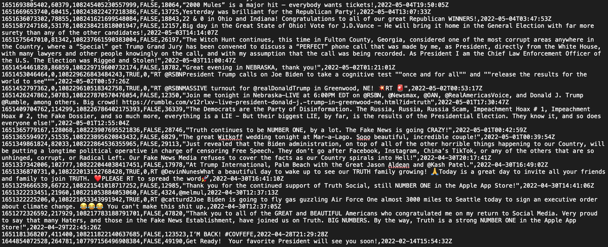

tweet example

## Base R string functions

### tolower() and toupper()

These two change the case of a string variable either to entirely upper case or entirely lower case. In this teaching example, we actually show the changes. In a real example, a programmer would simply change the case and check to make sure it worked and possibly comment out the check so it won’t run again:

```r
tolower(ufo_base$comments) |> head()
```

```
[1] "this event took place in early fall around 1949-50. it occurred after a boy scout meeting in the baptist church. the baptist church sit"
[2] "1949 lackland afb&#44 tx.  lights racing across the sky &amp; making 90 degree turns on a dime."
[3] "green/orange circular disc over chester&#44 england"
[4] "my older brother and twin sister were leaving the only edna theater at about 9 pm&#44...we had our bikes and i took a different route home"
[5] "as a marine 1st lt. flying an fj4b fighter/attack aircraft on a solo night exercise&#44 i was at 50&#44000&#39 in a &quot;clean&quot; aircraft (no ordinan"
[6] "my father is now 89 my brother 52 the girl with us now 51 myself 49 and the other fellow which worked with my father if he&#39s still livi"
```

a more detailed example

```r
tolower(ufo_base$comments) |> strsplit(split = " ") |> unlist() |> table() |> sort() |> tail(n = 20)
```

```
moving     it     on   with    sky     at    was bright object   over      i
  8641   9330   9350   9885  11168  11333  12384  12463  13315  13704  15102
lights  light     to     of           and      a     in    the
 15172  15778  16060  20835  21550  25575  31392  33352  36175
```

## paste() and paste0()

You can form longer strings with `paste()` and `paste0()` Basic syntax for paste (vector1, vector2, …, vectorN) defaults to putting a space between the vector values. Alternative is to specify the separator with the option “sep=”.

```r
load("collison.RData")
collison$descent_gender <- paste(collison$Victim_Descent, collison$Victim_Sex, sep = "-")
table(collison$descent_gender)
```

```
   A-F    A-M    A-X    B-F    B-M    B-X    H-F    H-M    H-X  O/U-F  O/U-M
 14109  16754     60  38281  43265     18  86643 146034    100  32709  70468
 O/U-X    W-F    W-M    W-X
 27804  53344  86599     55
```

paste0 has no separator

```r
paste0(collison$Victim_Descent, collison$Victim_Sex, 26) |> table()
```

```
  AF26   AM26   AX26   BF26   BM26   BX26   HF26   HM26   HX26 O/UF26 O/UM26
 14109  16754     60  38281  43265     18  86643 146034    100  32709  70468
O/UX26   WF26   WM26   WX26
 27804  53344  86599     55
```